# p8105_hw6_yz5290

2025-12-03

```r
library(tidyverse)
library(broom)
library(modelr)
```

p1

```r
homicide=
  read_csv("data/homicide-data.csv")|>
  janitor::clean_names()|>
  mutate(city_state = str_c(city, ", ", state)) |>
  mutate(solved = as.numeric(disposition == "Closed by arrest")) |>
  filter(!city_state %in% c("Dallas, TX", "Phoenix, AZ",
                           "Kansas City, MO", "Tulsa, AL")) |>
  filter(victim_race %in% c("White", "Black")) |>
  mutate(victim_age = as.numeric(victim_age)) |>
  filter(!is.na(victim_age))
#Baltimore
baltimore_data =
  homicide |>
  filter(city_state == "Baltimore, MD")
baltimore_model =
  glm(solved ~ victim_age + victim_sex + victim_race,
      data = baltimore_data,
      family = binomial())
baltimore_results =
  baltimore_model |>
  tidy(conf.int = TRUE) |>
  filter(term == "victim_sexMale") |>
  mutate(
    OR = exp(estimate),
    OR_CI_low = exp(conf.low),
    OR_CI_high = exp(conf.high),
    city_state = "Baltimore, MD"
  ) |>
  select(city_state, OR, OR_CI_low, OR_CI_high)
```

```r
baltimore_results
```

```
## # A tibble: 1 × 4
##   city_state       OR OR_CI_low OR_CI_high
##   <chr>         <dbl>     <dbl>      <dbl>
## 1 Baltimore, MD 0.426     0.324      0.558
```

```
## `height` was translated to `width`.
```

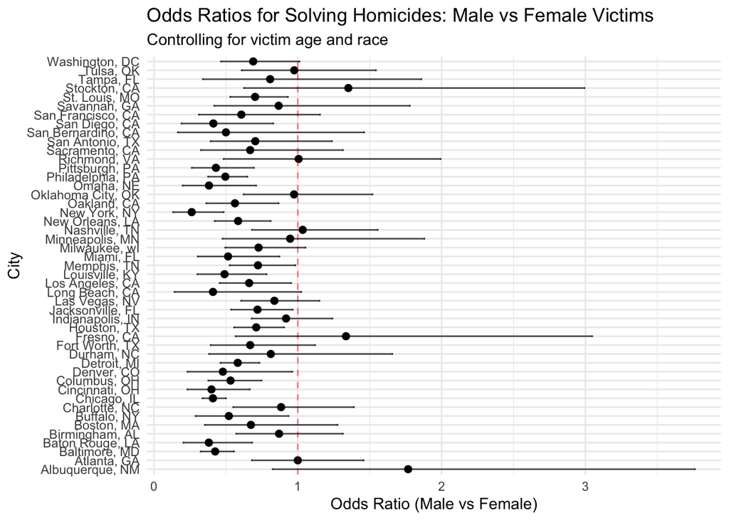

```r
fit_city_model = function(city_df) {
  model_fit =
    glm(solved ~ victim_age + victim_sex + victim_race,
        data = city_df,
        family = binomial())
  model_fit |>
    tidy(conf.int = TRUE) |>
    filter(term == "victim_sexMale") |>
    mutate(
      OR = exp(estimate),
      OR_CI_low = exp(conf.low),
      OR_CI_high = exp(conf.high)
    ) |>
    select(OR, OR_CI_low, OR_CI_high)
}
city_results =
  homicide |>
  group_by(city_state) |>
  filter(n() >= 10) |>
  nest() |>
  mutate(
    model_results = map(data, ~possibly(fit_city_model, otherwise = NULL)(.x))
  ) |>
  filter(!map_lgl(model_results, is.null)) |>
  unnest(model_results) |>
  select(-data) |>
  arrange(OR)
#make plot
city_plot =
  city_results |>
  mutate(city_state = fct_reorder(city_state, OR)) |>
  ggplot(aes(x = OR, y = city_state)) +
  geom_point(size = 2)+
  geom_vline(xintercept = 1, linetype = "dashed",
             color = "red", alpha = 0.5) +
  geom_errorbarh(aes(xmin = OR_CI_low, xmax = OR_CI_high),
                 height = 0.2, alpha = 0.7) +
  labs(
    title = "Odds Ratios for Solving Homicides: Male vs Female Victims",
    subtitle = "Controlling for victim age and race",
    x = "Odds Ratio (Male vs Female)",
    y = "City"
  ) +
  theme_minimal()
city_plot
```

#this graph shows that most of points is smaller than 1, which means widespread pattern of lower clearance for male victims. Overall, homicides with female victims are more likely to be solved than those with male victims,

p2

```r
library(p8105.datasets)
data("weather_df")
```

```r
weather_df=
  weather_df|>
  select(tmin, tmax, prcp)
```

```r
#boot

set.seed(123)
n_boot=5000

weather_boot_results =
  weather_df |>
  bootstrap(n = 5000) |>
  mutate(
    # Convert strap to tibble
    df = map(strap, as_tibble),
    # Fit linear model
    fits = map(df, ~lm(tmax ~ tmin + prcp, data = .x)),
    # Extract coefficients
    betas = map(fits, broom::tidy),
    # Extract R-squared
    rsquared = map(fits, broom::glance)
  ) |>
  # Unnest the results
  select(.id, betas, rsquared) |>
  unnest(c(betas, rsquared), names_sep = "_") |>
  # Select relevant columns
  select(.id, betas_term, betas_estimate, rsquared_r.squared) |>
  # Remove intercept
  filter(betas_term != "(Intercept)") |>
  # Calculate beta1/beta2 (tmin coefficient / prcp coefficient)
  group_by(.id) |>
  summarize(
    r_squared = first(rsquared_r.squared),
    beta1 = betas_estimate[betas_term == "tmin"],
    beta2 = betas_estimate[betas_term == "prcp"],
    beta_ratio = beta1 / beta2
  )
```

```r
#summary
boot_summary =
  weather_boot_results |>
  summarise(
    r2_mean = mean(r_squared),
    r2_sd = sd(r_squared),
    r2_ci_low = quantile(r_squared, 0.025),
    r2_ci_high = quantile(r_squared, 0.975),
    ratio_mean = mean(beta_ratio),
    ratio_sd = sd(beta_ratio),
    ratio_ci_low = quantile(beta_ratio, 0.025),
    ratio_ci_high = quantile(beta_ratio, 0.975)
  )
boot_summary
```

```
## # A tibble: 1 × 8
##   r2_mean   r2_sd r2_ci_low r2_ci_high ratio_mean ratio_sd ratio_ci_low
##     <dbl>   <dbl>     <dbl>      <dbl>      <dbl>    <dbl>        <dbl>
## 1   0.941 0.00315     0.934      0.947      -186.     40.3        -279.
## # ℹ 1 more variable: ratio_ci_high <dbl>
```

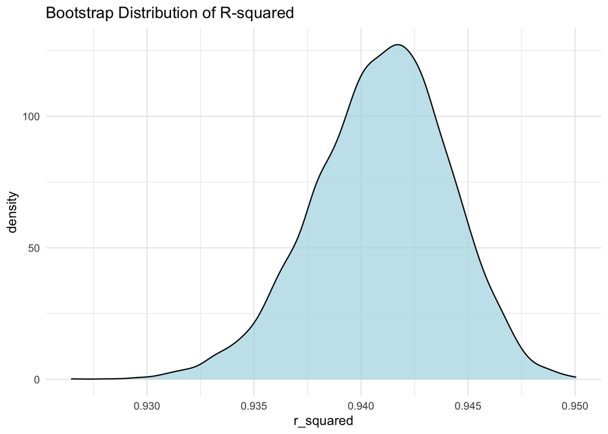

```r
p1 =
  weather_boot_results |>
  ggplot(aes(x = r_squared)) +
  geom_density(fill = "lightblue", alpha = 0.7) +
  labs(
    title = "Bootstrap Distribution of R-squared"
  ) +
  theme_minimal()
p1
```

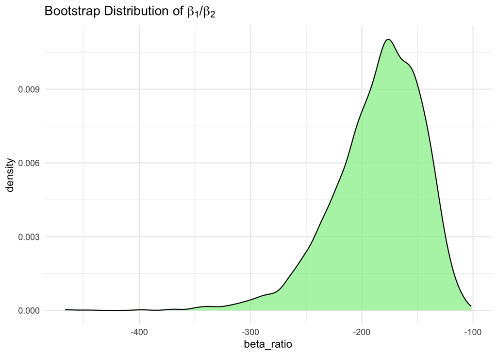

```r
p2 =
 weather_boot_results |>
  ggplot(aes(x = beta_ratio)) +
  geom_density(fill = "lightgreen", alpha = 0.7) +
  labs(
    title = expression(paste("Bootstrap Distribution of ", beta[1], "/", beta[2]))
  ) +
  theme_minimal()
p2
```

#for plot1: The R squared value is around 0.942 is in the range of confidence interval (0.934, 0.947). THe r squred disbution is a little bit left skewed.

#for plot 2: The distribution of beta coeifficient is somehow left skewed with the negative peak-180, which suggest that coefficient for tmin and prcp have opposite signs. The 95% CI (-279, -125) suggests a fairly tight distribution

P3

```r
birthweight=
  read_csv("data/birthweight.csv")|>
  janitor::clean_names()|>
  mutate(
    babysex = factor(babysex, labels = c("male", "female")),
    frace = factor(frace,
                  levels = c(1, 2, 3, 4, 8, 9),
                  labels = c("White", "Black", "Asian",
                            "Puerto Rican", "Other", "Unknown")),
    malform = factor(malform, levels = c(0, 1), labels = c("absent", "present")),
    mrace = factor(mrace,
                  levels = c(1, 2, 3, 4, 8),
                  labels = c("White", "Black", "Asian",
                            "Puerto Rican", "Other"))
  )
#check for missing values
birthweight |>
  summarise(across(everything(), ~sum(is.na(.)))) |>
  pivot_longer(everything()) |>
  filter(value > 0)
```

```
## # A tibble: 0 × 2
## # ℹ 2 variables: name <chr>, value <int>
```

```r
#model1
#I want to explore socioeconomic like finial situation, mother's race and parity and behavioral determinants like smoking relate to birthweight. so i include variable fincome, momage, smoken,, mrace, arity and pp bmi. pp bmi act like a control.


my_original_model = lm(
  bwt ~ fincome + momage + smoken + mrace + parity + ppbmi,
  data = birthweight
)

# Model summary
summary_my_model = tidy(my_original_model, conf.int = TRUE)
summary_my_model
```

```
## # A tibble: 9 × 7
##   term              estimate std.error statistic  p.value  conf.low conf.high
##   <chr>                <dbl>     <dbl>     <dbl>    <dbl>     <dbl>     <dbl>
## 1 (Intercept)       2864.       63.6      45.0   0        2739.       2989.
## 2 fincome              0.674     0.313     2.15  3.14e- 2    0.0600      1.29
## 3 momage               1.93      2.08      0.926 3.54e- 1   -2.16        6.02
## 4 smoken             -11.2       1.01    -11.1   3.57e-28  -13.2        -9.26
## 5 mraceBlack        -347.       17.4     -19.9   3.77e-84 -381.       -312.
## 6 mraceAsian        -136.       74.8      -1.82  6.87e- 2 -283.         10.4
## 7 mracePuerto Rican -240.       33.2      -7.24  5.38e-13 -305.       -175.
## 8 parity             -25.8      70.8      -0.364 7.16e- 1 -165.        113.
## 9 ppbmi               18.3       2.31      7.92  3.04e-15   13.8        22.9
```

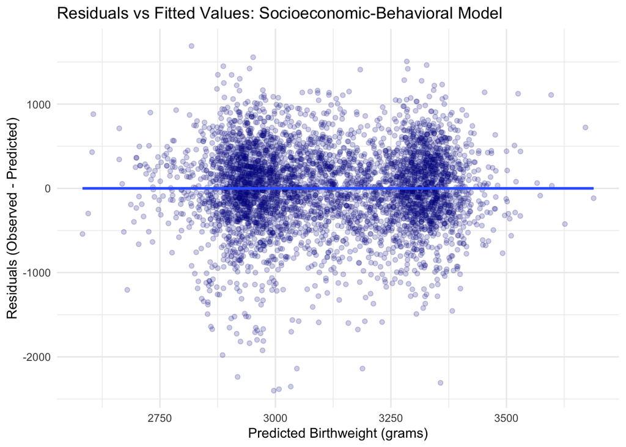

```r
#make the residual plot
residual_plot1 =
  birthweight |>
  add_predictions(my_original_model) |>
  add_residuals(my_original_model) |>
  ggplot(aes(x = pred, y = resid)) +
  geom_point(alpha = 0.2, color = "darkblue") +
  geom_smooth(se = FALSE) +
  labs(
    title = "Residuals vs Fitted Values: Socioeconomic-Behavioral Model",
    x = "Predicted Birthweight (grams)",
    y = "Residuals (Observed - Predicted)"
  ) +
  theme_minimal()
residual_plot1
```

#residual for Socioeconomic-Behavioral Model are not raonld scattered. The clustering suggests the model struggles to predict the full range of birthweights, particularly for extreme values. Points mainly cluster aounrd 2900 and 3300 predicted birth weights. There is unequal variance across predictions beacuse there are more points in lower region.The model may be adequate for “average” birthweights but less reliable for low or high birthweight cases

```r
#model1: using length at birth and gestational age as predictors (main effects only)
model1 = lm(bwt ~ blength + gaweeks, data = birthweight)
#model2:using head circumference, length, sex, and all interactions (including the three-way interaction) between these
model2 = lm(bwt ~ bhead * blength * babysex, data = birthweight)

model1
```

```
##
## Call:
## lm(formula = bwt ~ blength + gaweeks, data = birthweight)
##
## Coefficients:
## (Intercept)      blength      gaweeks
##    -4347.67       128.56        27.05
```

```r
model2
```

```
##
## Call:
## lm(formula = bwt ~ bhead * blength * babysex, data = birthweight)
##
## Coefficients:
##                 (Intercept)                        bhead
##                  -7176.8170                     181.7956
##                     blength                babysexfemale
##                    102.1269                    6374.8684
##               bhead:blength          bhead:babysexfemale
##                     -0.5536                    -198.3932
##       blength:babysexfemale  bhead:blength:babysexfemale
##                   -123.7729                       3.8781
```

```r
# Cross-validation framework

set.seed(123)
cv_df =
  crossv_mc(birthweight, n = 100) |>
  mutate(
    train = map(train, as_tibble),
    test = map(test, as_tibble)
  )
```

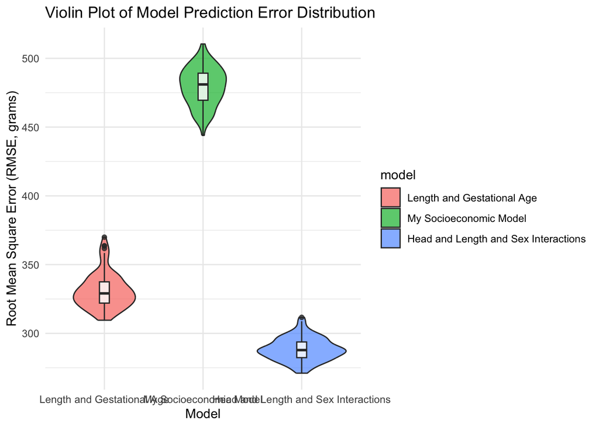

```r
# Fit models in cross-validation
cv_df1 = cv_df |>
  mutate(
    # My model
    my_fit = map(train, \(df) lm(bwt ~ fincome + momage + smoken + mrace + parity + ppbmi,
                                 data = df)),
    # Comparison model 1
    no_inter_fit = map(train, \(df) lm(bwt ~ blength + gaweeks, data = df)),
    # Comparison model 2
    w_inter_fit = map(train, \(df) lm(bwt ~ bhead * blength * babysex, data = df))
  ) |>
  mutate(
    rmse_my_model = map2_dbl(my_fit, test, rmse),
    rmse_no_inter = map2_dbl(no_inter_fit, test, rmse),
    rmse_w_inter = map2_dbl(w_inter_fit, test, rmse)
  )
  violin_plot =
  cv_df1 |>
  select(starts_with("rmse")) |>
  pivot_longer(
    everything(),
    names_to = "model",
    values_to = "rmse",
    names_prefix = "rmse_"
  ) |>
  mutate(
    model = case_when(
      model == "my_model" ~ "My Socioeconomic Model",
      model == "no_inter" ~ "Length and Gestational Age",
      model == "w_inter" ~ "Head and Length and Sex Interactions"
    ),
    model = factor(model, levels = c("Length and Gestational Age",
                                     "My Socioeconomic Model",
                                     "Head and Length and Sex Interactions"))
  ) |>
  ggplot(aes(x = model, y = rmse, fill = model)) +
  geom_violin(alpha = 0.7) +
  geom_boxplot(width = 0.1, fill = "white", alpha = 0.8) +
  labs(
    title = "Violin Plot of Model Prediction Error Distribution",
    x = "Model",
    y = "Root Mean Square Error (RMSE, grams)"
  ) +
  theme_minimal()
violin_plot
```